# MSBA Course Preference Segmentation

K-Means, Hierarchical Clustering, and Latent Class MaxDiff

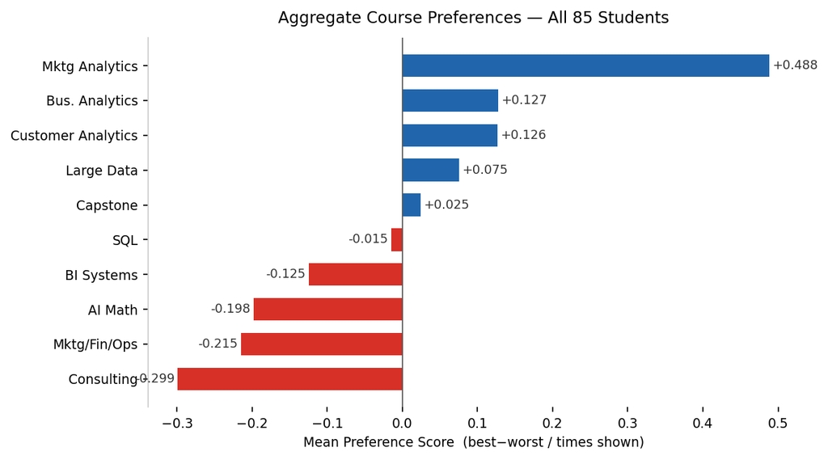

## Choosing k = 3

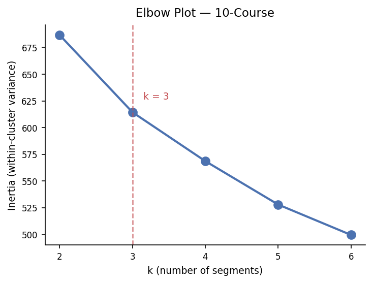

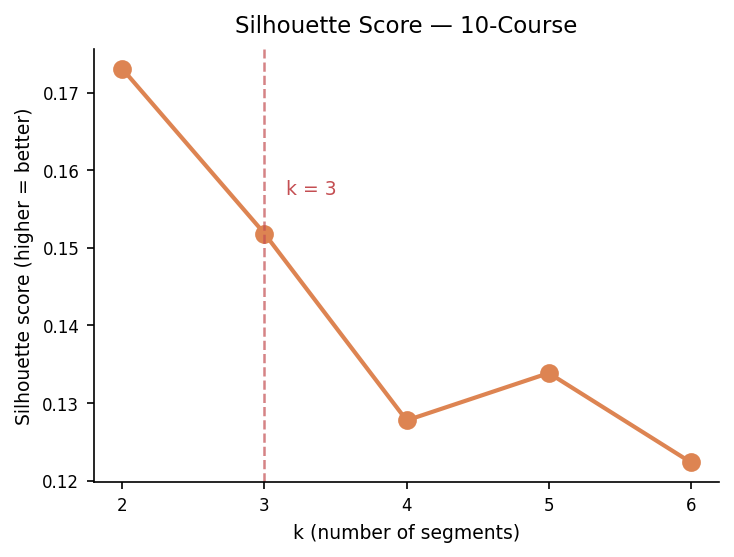

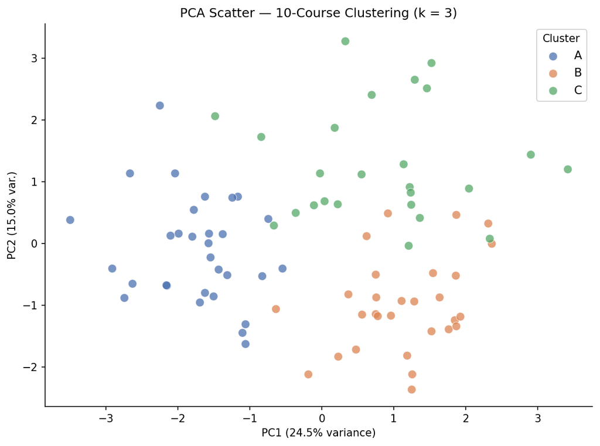

**Elbow:** look for where inertia improvement slows. **Silhouette:** higher is better, but interpretability and balanced segment sizes also matter. **k = 3 is chosen** because it is interpretable and balanced. **PCA** shows clusters overlap softly, so structure is real but not sharp.

## K-Means: Three Preference Segments

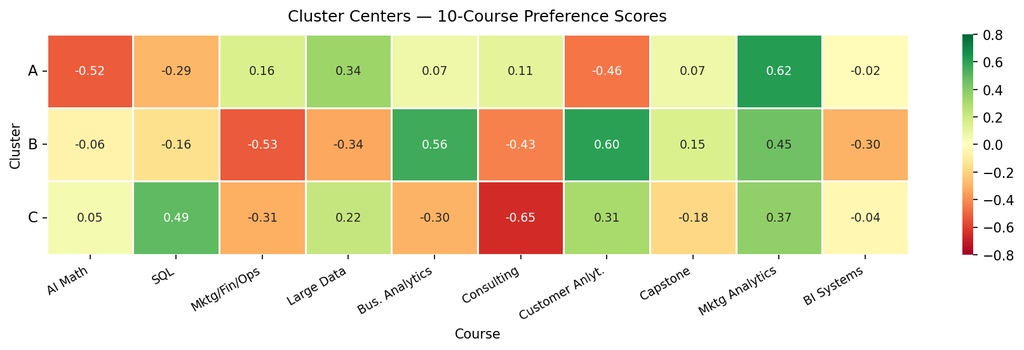

Cluster centers — green = preferred, red = avoided. Three anonymous clusters A, B, C. What does each group prefer?

Cluster A — Mktg Analytics & Big Data (n = 31)

↑ Likes: Marketing Analytics, Large Data

↓ Dislikes: AI Math, Customer Analytics

Cluster B — Applied Analytics Seekers (n = 29)

↑ Likes: Customer Analytics, Bus. Analytics

↓ Dislikes: Mktg/Fin/Ops, Consulting

Cluster C — Quant & Technical (n = 25)

↑ Likes: SQL, Marketing Analytics

↓ Dislikes: Consulting, Mktg/Fin/Ops

## Hierarchical Clustering: Validation

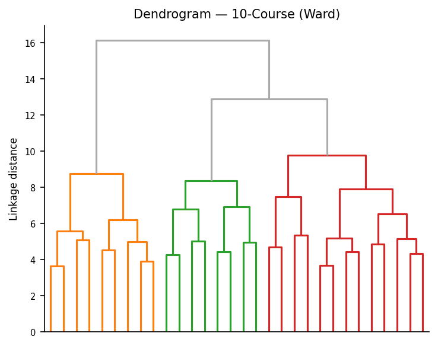

Dendrogram — Ward linkage, cut at k = 3.

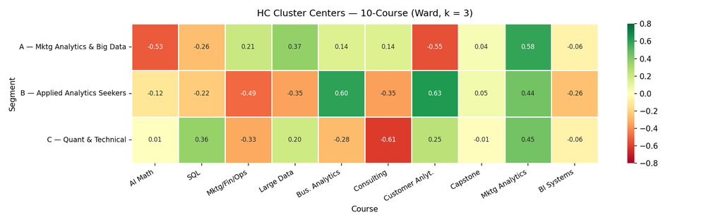

HC cluster centers — same three preference profiles emerge from a different algorithm.

Hierarchical clustering gives a robustness check using Ward linkage. It recovers a similar three-segment structure to k-means. ARI vs K-Means = 0.70

## Latent Class MaxDiff: Validation

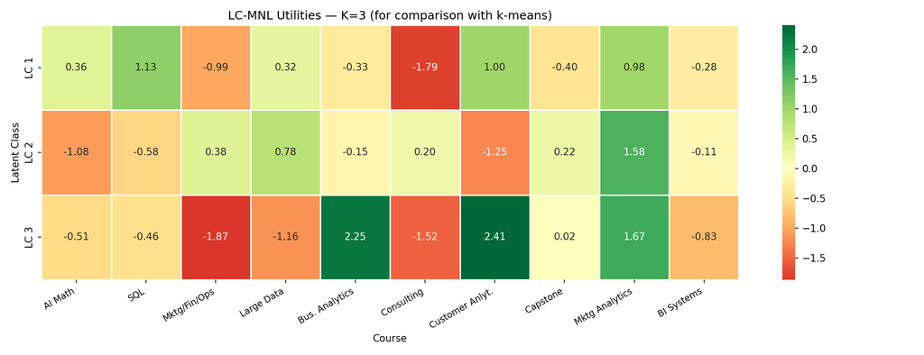

LC-MNL K = 3 class utilities. Three classes with distinct preference patterns — LC 1, LC 2, LC 3.

**What it is:** A probabilistic choice model estimated directly from the original best/worst survey responses. It estimates class-specific course utilities and assigns each student to a latent class — no derived scores needed.

**Why it validates:** Uses raw MaxDiff choices rather than derived preference scores. If it recovers similar groups, that strengthens confidence in the K-Means segments. ARI vs K-Means = 0.69

LC 1 — Quant & Technical

↓ Dislikes: Consulting, Mktg/Fin/Ops

LC 2 — Mktg Analytics & Big Data

↑ Likes: Marketing Analytics, Large Data

↓ Dislikes: AI Math, Customer Analytics

LC 3 — Applied Analytics Seekers

↑ Likes: Customer Analytics, Bus. Analytics

↓ Dislikes: Consulting, Mktg/Fin/Ops

## Model Comparison

| Model | Input Used | What It Optimizes | Strength | Limitation | Segment Story |
| --- | --- | --- | --- | --- | --- |
| K-Means | Per-student preference scores (best − worst ÷ times shown) | Minimize within-cluster variance | Fast; cluster centers directly interpretable in original preference score units | Tends to produce similarly-sized groups; k must be chosen before fitting | A — Mktg Analytics & Big Data (31) B — Applied Analytics Seekers (29) C — Quant & Technical (25) |
| Hierarchical Clustering | Same preference scores | Minimise variance at each successive merge step (Ward linkage) | No k required upfront; dendrogram reveals similarity between groups | Students cannot be reassigned after a merge; borderline cases may differ from K-Means | Same 3 groups · ARI = 0.70 7 in 10 students assigned identically |
| Latent Class MaxDiff | Raw best/worst choice tasks from the survey | Maximise choice log-likelihood via EM; class utilities from actual responses | Uses original survey data directly; most appropriate method for MaxDiff design; fit statistics guide K selection | K = 3 and K = 4 nearly tied in fit (ΔBIC < 1); results depend on random starting values | Same 3 groups · ARI = 0.69 Three classes mirror K-Means segments |